# Reproducible Research: Peer Assessment 1

Done by: DT

6/6/2020

## Introduction

It is now possible to collect a large amount of data about personal movement using activity monitoring devices such as a [Fitbit](http://www.fitbit.com), [Nike Fuelband](http://www.nike.com/us/en_us/c/nikeplus-fuelband), or [Jawbone Up](https://jawbone.com/up). These type of devices are part of the “quantified self” movement – a group of enthusiasts who take measurements about themselves regularly to improve their health, to find patterns in their behavior, or because they are tech geeks. But these data remain under-utilized both because the raw data are hard to obtain and there is a lack of statistical methods and software for processing and interpreting the data.

This assignment makes use of data from a personal activity monitoring device. This device collects data at 5 minute intervals through out the day. The data consists of two months of data from an anonymous individual collected during the months of October and November, 2012 and include the number of steps taken in 5 minute intervals each day.

## Data

The data for this assignment can be downloaded from the course web site:

- Dataset: [Activity monitoring data](https://d396qusza40orc.cloudfront.net/repdata%2Fdata%2Factivity.zip) [52K]

The variables included in this dataset are:

- **steps**: Number of steps taking in a 5-minute interval (missing values are coded as `NA`)
- **date**: The date on which the measurement was taken in YYYY-MM-DD format
- **interval**: Identifier for the 5-minute interval in which measurement was taken

The dataset is stored in a comma-separated-value (CSV) file and there are a total of 17,568 observations in this dataset.

# Loading and preprocessing the data

Show any code that is needed to

1. Load the data (i.e. read.csv())
2. Process/transform the data (if necessary) into a format suitable for your analysis

```r
library(lubridate)
setwd("C:/Users/Osmiu/my_git_project/RepData_peerAssessment1")

activity <- read.csv("activity.csv", header=TRUE, na.strings = "NA")


#format date class
activity$date <- ymd(activity$date)
```

# Quick check

```r
summary(activity)
```

```
##      steps             date               interval
##  Min.   :  0.00   Min.   :2012-10-01   Min.   :   0.0
##  1st Qu.:  0.00   1st Qu.:2012-10-16   1st Qu.: 588.8
##  Median :  0.00   Median :2012-10-31   Median :1177.5
##  Mean   : 37.38   Mean   :2012-10-31   Mean   :1177.5
##  3rd Qu.: 12.00   3rd Qu.:2012-11-15   3rd Qu.:1766.2
##  Max.   :806.00   Max.   :2012-11-30   Max.   :2355.0
##  NA's   :2304
```

```r
str(activity)
```

```
## 'data.frame':    17568 obs. of  3 variables:
##  $ steps   : int  NA NA NA NA NA NA NA NA NA NA ...
##  $ date    : Date, format: "2012-10-01" "2012-10-01" ...
##  $ interval: int  0 5 10 15 20 25 30 35 40 45 ...
```

# 1. What is mean total number of steps taken per day?

For this part of the assignment, you can ignore the missing values in the dataset.

#To remove the NAs and sum steps by date

```r
activity_steps_day <- aggregate(steps ~ date, data = activity, FUN = sum, na.rm = TRUE)
```

# 2. Make a histogram of the total number of steps taken each day

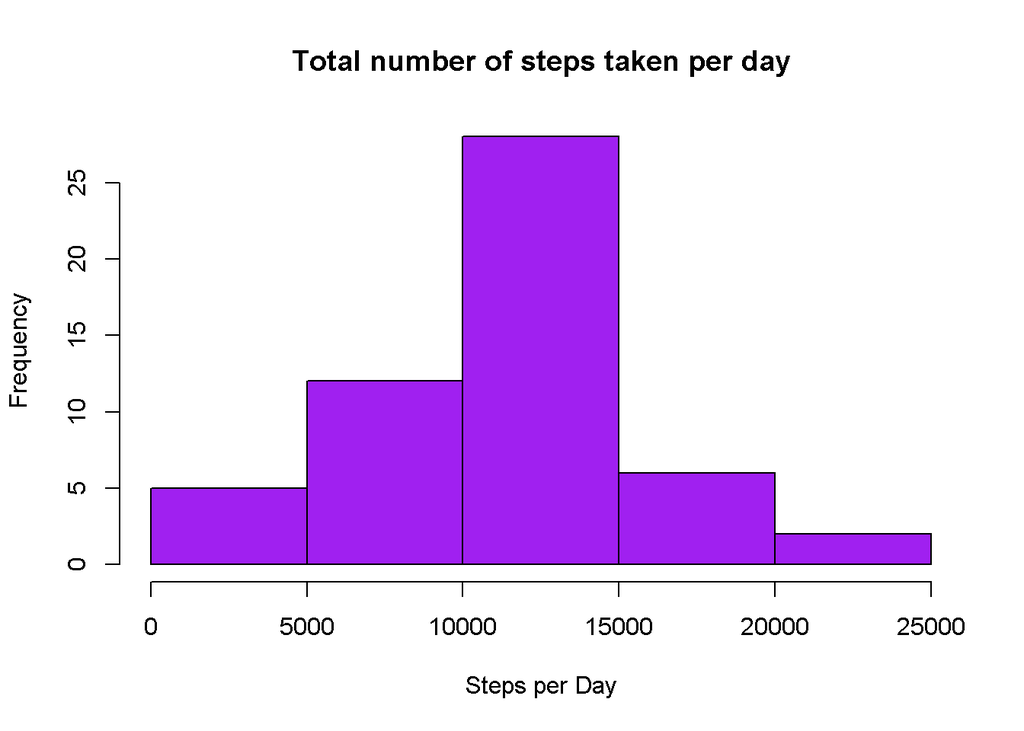

```r
hist(activity_steps_day$steps, xlab = "Steps per Day", main = "Total number of steps taken per day", col = "Purple")
```

2. Calculate and report the mean and median total number of steps taken per day

```r
mean_steps <- mean(activity_steps_day$steps)
median_steps <- median(activity_steps_day$steps)

x <- format(mean_steps, digit=1)
y <- format(median_steps, digit=1)
```

Mean total number of steps per day: **10766**  
Median total number of steps per day: **10765**

# What is the average daily activity pattern?

# 1. Make a time series plot (i.e. type = “l”) of the 5-minute interval (x-axis) and the average number of steps taken, averaged across all days (y-axis)

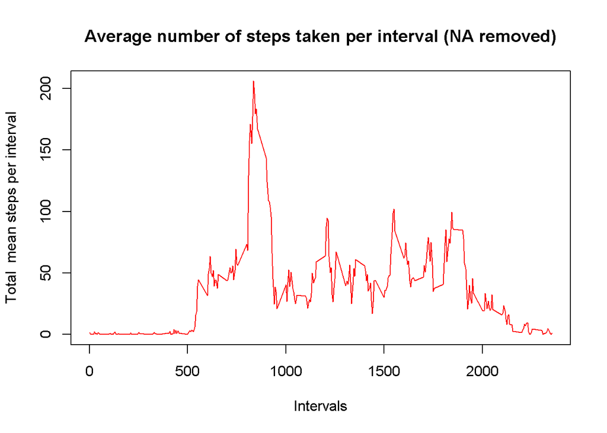

```r
#set up data frame by using Aggregate function for mean of steps over all days, for each interval
activity_steps_mean_int <- aggregate(steps ~ interval, data = activity, FUN = mean, na.rm = TRUE)

#Plot graph
plot(activity_steps_mean_int$interval, activity_steps_mean_int$steps, type = "l", col = "Red", xlab = "Intervals", ylab = "Total  mean steps per interval", main = "Average number of steps taken per interval (NA removed)")
```

# 2. Which 5-minute interval, on average across all the days in the dataset, contains the maximum number of steps?

```r
#what is the maximum mean steps value? (maximum steps on one given interval)
max_mean_steps <-max(activity_steps_mean_int$steps)
#for which interval are the numbers of steps per interval at the highest?
max_mean_steps_interval <- activity_steps_mean_int$interval[which(activity_steps_mean_int$steps==max_mean_steps)]
```

The maximum number of steps for a 5 minutes interval is **206.1698113**,  
which is at **835** interval.

# Imputing missing values

## 1. Calculate total number of missing values in the dataset

```r
x <- sum(is.na(activity))
```

The total number of missing values in the dataset is **2304**

## 2. Devise a strategy for filling in all of the missing values in the dataset

```r
Replace_NA_activity <- activity
Replace_NA_activity$steps[is.na(Replace_NA_activity$steps)] <- mean(Replace_NA_activity$steps,na.rm=TRUE)
Replace_NA_activity$steps <- as.numeric(Replace_NA_activity$steps)
Replace_NA_activity$interval <- as.numeric(Replace_NA_activity$interval)

# this is to check if there are any 'NA'
colSums(is.na(Replace_NA_activity))
```

```
##    steps     date interval
##        0        0        0
```

## 3. Create new dataset with the missing data filled in

```r
summary(Replace_NA_activity)
```

```
##      steps             date               interval
##  Min.   :  0.00   Min.   :2012-10-01   Min.   :   0.0
##  1st Qu.:  0.00   1st Qu.:2012-10-16   1st Qu.: 588.8
##  Median :  0.00   Median :2012-10-31   Median :1177.5
##  Mean   : 37.38   Mean   :2012-10-31   Mean   :1177.5
##  3rd Qu.: 37.38   3rd Qu.:2012-11-15   3rd Qu.:1766.2
##  Max.   :806.00   Max.   :2012-11-30   Max.   :2355.0
```

## 4. Make a histogram of the total number of steps taken each day

```r
Replace_NA_activity2 <- aggregate(steps ~ date, data = Replace_NA_activity, FUN=sum)
```

```r
summary(Replace_NA_activity2)
```

```
##       date                steps
##  Min.   :2012-10-01   Min.   :   41
##  1st Qu.:2012-10-16   1st Qu.: 9819
##  Median :2012-10-31   Median :10766
##  Mean   :2012-10-31   Mean   :10766
##  3rd Qu.:2012-11-15   3rd Qu.:12811
##  Max.   :2012-11-30   Max.   :21194
```

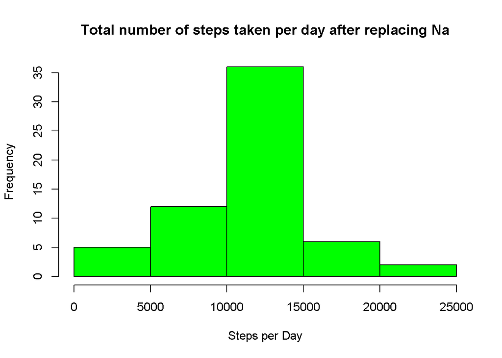

```r
hist(Replace_NA_activity2$steps, xlab = "Steps per Day", main = "Total number of steps taken per day after replacing Na", col = "Green")
```

```r
mean_steps_NA_replaced <- mean(Replace_NA_activity2$steps)
median_steps_NA_replaced <- median(Replace_NA_activity2$steps)

x <- format(mean_steps_NA_replaced, digit=1)
y <- format(median_steps_NA_replaced, digit=1)
```

Mean total number of steps taken per day after replacing NA = **10766**.

Median total number of steps taken per day after replacing NA = **10766**.

# Create a new factor variable in the dataset with two levels – “weekday” and “weekend” indicating whether a given date is a weekday or weekend day.

```r
Replace_NA_activity$dayType <- ifelse(weekdays(as.Date(Replace_NA_activity$date)) == "Saturday" | weekdays(as.Date(Replace_NA_activity$date)) == "Sunday", "Weekend", "Weekday")
```

```r
Replace_NA_activity$dayType <- factor(Replace_NA_activity$dayType)
```

```r
str(Replace_NA_activity)
```

```
## 'data.frame':    17568 obs. of  4 variables:
##  $ steps   : num  37.4 37.4 37.4 37.4 37.4 ...
##  $ date    : Date, format: "2012-10-01" "2012-10-01" ...
##  $ interval: num  0 5 10 15 20 25 30 35 40 45 ...
##  $ dayType : Factor w/ 2 levels "Weekday","Weekend": 1 1 1 1 1 1 1 1 1 1 ...
```

###2. Panel plot containing time series plot

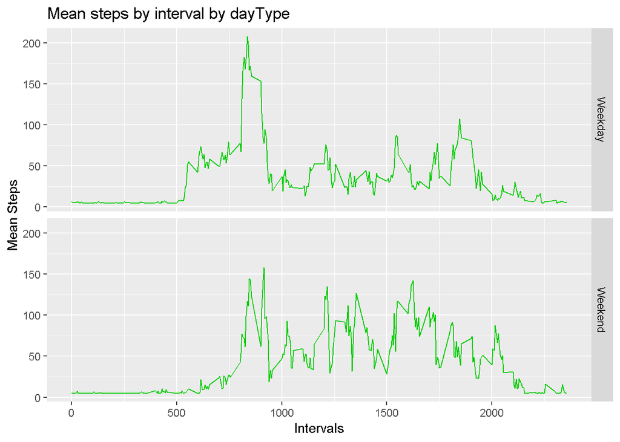

```r
#Create new data frame using aggregate function with steps, interval and  daytype

table_steps_interval_dayType <- aggregate(steps ~ interval + dayType, data = Replace_NA_activity, FUN = mean)

library(ggplot2)
#plot panel plot

plot <- ggplot(table_steps_interval_dayType, aes(interval, steps, dayType))
plot + geom_line(color = "green3") + facet_grid(dayType~.) + labs(x = "Intervals", y = "Mean Steps", title = "Mean steps by interval by dayType")
```